We first initialize the `tidyverse` library that contains `dplyr` and ``ggplot2`.

```r
library(tidyverse)
```

Let’s import the data.

```r
setwd("/Users/mathieu/Lab/company-electricity-statistical-analysis/src/")
df <- read.csv2(file = "electricity_consumption_dataset.txt", sep = ";", dec = ".")
head(df)
```

```
##           Y         X
## 1 16.290510  4.667310
## 2 11.572919  5.048043
## 3 20.772148  6.120283
## 4 20.732848 13.202527
## 5  9.426162  4.476845
## 6 21.584711 12.548479
```

This data contains 2 variables: **X: Electricity consumption (MWh)** and **Y = Productivity (1000€ / day)**.  
We rename the variables accordingly.

```r
df <- rename(df, electricity_consumption = X, productivity = Y)
```

## 1. Fitting naively a linear model.

We want to fit a linear model on our data. Is there a linear relationship between the **electricity consumption** and the **productivity** ? We can plot a *scatter plot* in order to visualize the relationship between these 2 variables.

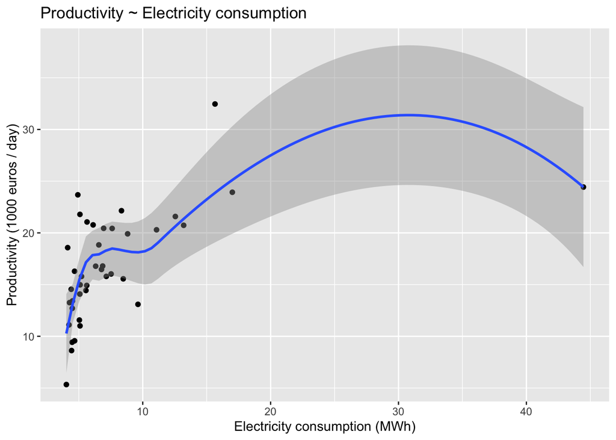

```r
ggplot(df, aes(x = electricity_consumption, y = productivity)) +
  geom_jitter() +
  geom_smooth() +
  ggtitle("Productivity ~ Electricity consumption") +
  xlab("Electricity consumption (MWh)") +
  ylab("Productivity (1000 euros / day)")
```

As we can see, this does not seem linear at all. We can still try to fit a linear model.
We use the **ordinary least square (OLS)** method that consists in minimising the sum of the square of the error:
$$\text{SSE} = \sum_{i = 0}^{+n} (y_i - \hat{y}_i)^2$$

We can do that easily in r

```r
simple_lm <- lm(productivity ~ electricity_consumption, data = df)
summary(simple_lm)
```

```
##
## Call:
## lm(formula = productivity ~ electricity_consumption, data = df)
##
## Residuals:
##     Min      1Q  Median      3Q     Max
## -9.9816 -2.3189 -0.3405  2.9626 12.5203
##
## Coefficients:
##                         Estimate Std. Error t value Pr(>|t|)
## (Intercept)              13.7173     1.1097  12.362 6.91e-15 ***
## electricity_consumption   0.3975     0.1084   3.667 0.000747 ***
## ---
## Signif. codes:  0 '***' 0.001 '**' 0.01 '*' 0.05 '.' 0.1 ' ' 1
##
## Residual standard error: 4.55 on 38 degrees of freedom
## Multiple R-squared:  0.2614, Adjusted R-squared:  0.242
## F-statistic: 13.45 on 1 and 38 DF,  p-value: 0.0007472
```

This method is based on **4 assumptions** :  
- **Linearity**: the relationship between the variables X and Y is linear.  
- **Independence**: each observation is independent.  
- **Homoscedasticity**: the residuals have constant variance at every level.  
- **Normality**: the residuals are normaly distributed.

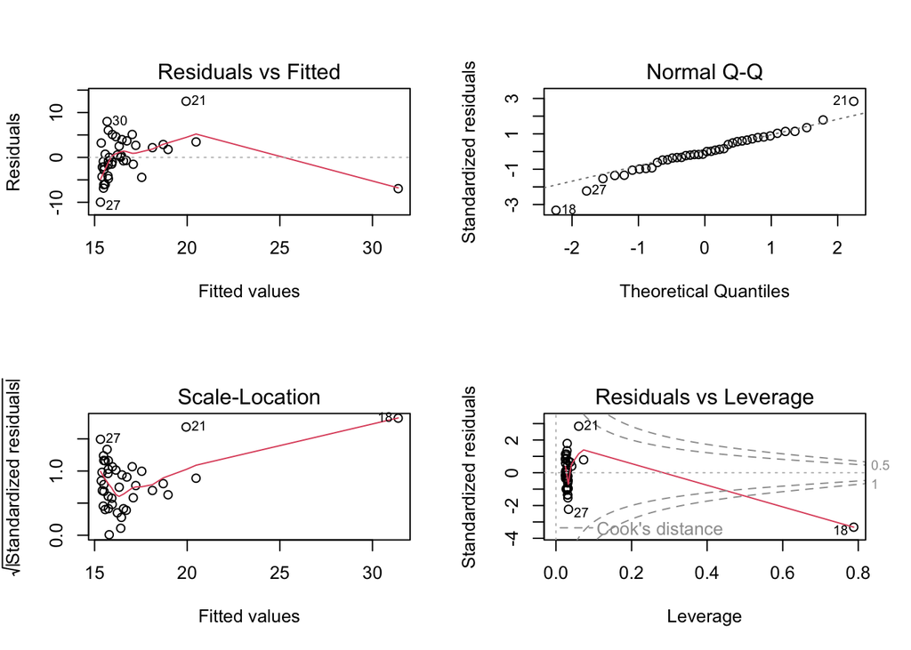

```r
par(mfrow = c(2,2))
plot(simple_lm)
```

### 1.1. Linearity

We can plot a *scatter plot* of the **residuals** again the **fitted values**.  
If there is a linear relationship, the points should be randomly distributed around the horizontal line $y = 0$.

As we can see in the **residual vs fitted** plot, the mean of the residuals is not $O$.

### 1.4. Normality

We want to make sure the residuals are normaly distributed so that our model is not consistently under- or over-predicting the values.  
In order to visualize that in r, we can plot an *histogram* of the residuals or a *qqplot*

We can see in the **qqplot** that the high and low values are pulling away from the dashed line.

## Model evaluation

We want to check if our model is reliable as a tool for understanding the phenomema we’re studying.

### R-Squared

The **R-Squared** is a number ranging from $0$ to $1$. It is commonly interpreted as indicating the **percentage of share of the variance in the dependent variable**.

Higher value of the **R-Squared** means that we explained more of the variation in our dependent variable.  
It should be noted that **R-Squared** can only increase as we add more variables but adding more variables does not automatically improve our model. Therefore, **Adjusted R-Squared** is a better metric in case of multiple linear regression as it decreases if the added variables do not improve the model.

```r
summary(simple_lm)
```

```
##
## Call:
## lm(formula = productivity ~ electricity_consumption, data = df)
##
## Residuals:
##     Min      1Q  Median      3Q     Max
## -9.9816 -2.3189 -0.3405  2.9626 12.5203
##
## Coefficients:
##                         Estimate Std. Error t value Pr(>|t|)
## (Intercept)              13.7173     1.1097  12.362 6.91e-15 ***
## electricity_consumption   0.3975     0.1084   3.667 0.000747 ***
## ---
## Signif. codes:  0 '***' 0.001 '**' 0.01 '*' 0.05 '.' 0.1 ' ' 1
##
## Residual standard error: 4.55 on 38 degrees of freedom
## Multiple R-squared:  0.2614, Adjusted R-squared:  0.242
## F-statistic: 13.45 on 1 and 38 DF,  p-value: 0.0007472
```

The **R-Squared** is $0.2614$ so $26%$ of the variation of the **productivity** is explained by the **electricity consumption**.

## 2. Transforming the variables

### 2.1. Square transformation

We first try improving our model by adding a square term.

```r
square_lm <- lm(productivity ~ electricity_consumption + I(electricity_consumption^2), data = df)
summary(square_lm)
```

```
##
## Call:
## lm(formula = productivity ~ electricity_consumption + I(electricity_consumption^2),
##     data = df)
##
## Residuals:
##     Min      1Q  Median      3Q     Max
## -7.8536 -2.4357 -0.3714  2.2440  9.2655
##
## Coefficients:
##                               Estimate Std. Error t value Pr(>|t|)
## (Intercept)                   7.162903   1.903969   3.762 0.000583 ***
## electricity_consumption       1.607098   0.318895   5.040 1.25e-05 ***
## I(electricity_consumption^2) -0.027426   0.006923  -3.962 0.000326 ***
## ---
## Signif. codes:  0 '***' 0.001 '**' 0.01 '*' 0.05 '.' 0.1 ' ' 1
##
## Residual standard error: 3.864 on 37 degrees of freedom
## Multiple R-squared:  0.4814, Adjusted R-squared:  0.4534
## F-statistic: 17.17 on 2 and 37 DF,  p-value: 5.301e-06
```

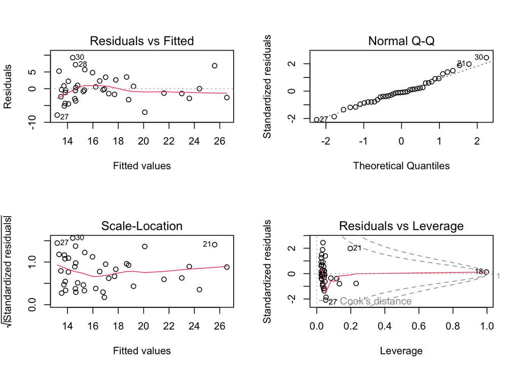

```r
par(mfrow = c(2,2))
plot(square_lm)
```

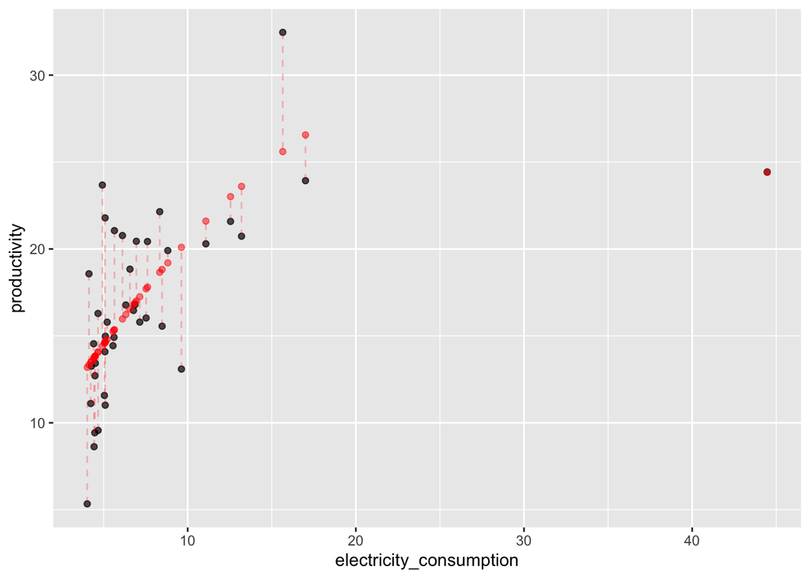

```r
ggplot(df, aes(x = electricity_consumption, y = productivity)) +
  geom_point(alpha = 0.7) +
  geom_point(aes(x = electricity_consumption, y = square_lm$fitted.values), color = "red", alpha = 0.5) +
  geom_segment(aes(xend = electricity_consumption, yend = square_lm$fitted.values), color = "red", alpha = 0.25, linetype = "dashed")
```

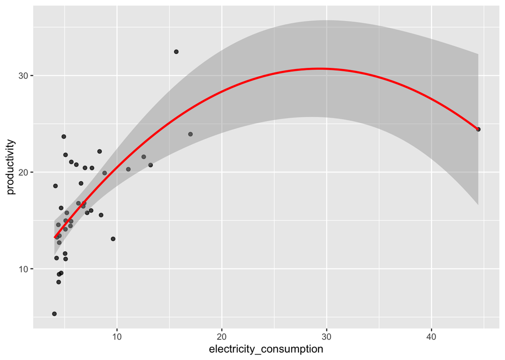

```r
ggplot(df, aes(x = electricity_consumption, y = productivity)) +
  geom_point(alpha = 0.75) +
  geom_smooth(method = "lm", formula = y ~ x + I(x^2), color = "red")
```

### 2.2. Log transformation

```r
log_lm <- lm(productivity ~  log(electricity_consumption), data = df)
summary(log_lm)
```

```
##
## Call:
## lm(formula = productivity ~ log(electricity_consumption), data = df)
##
## Residuals:
##     Min      1Q  Median      3Q     Max
## -7.9331 -1.8846 -0.3487  2.0075  9.5712
##
## Coefficients:
##                              Estimate Std. Error t value Pr(>|t|)
## (Intercept)                     3.400      2.552   1.332    0.191
## log(electricity_consumption)    7.085      1.306   5.423 3.52e-06 ***
## ---
## Signif. codes:  0 '***' 0.001 '**' 0.01 '*' 0.05 '.' 0.1 ' ' 1
##
## Residual standard error: 3.975 on 38 degrees of freedom
## Multiple R-squared:  0.4363, Adjusted R-squared:  0.4215
## F-statistic: 29.41 on 1 and 38 DF,  p-value: 3.518e-06
```

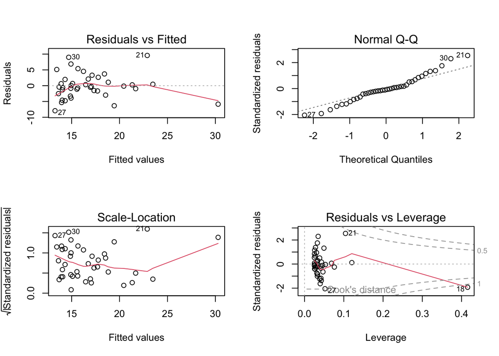

```r
par(mfrow = c(2,2))
plot(log_lm)
```

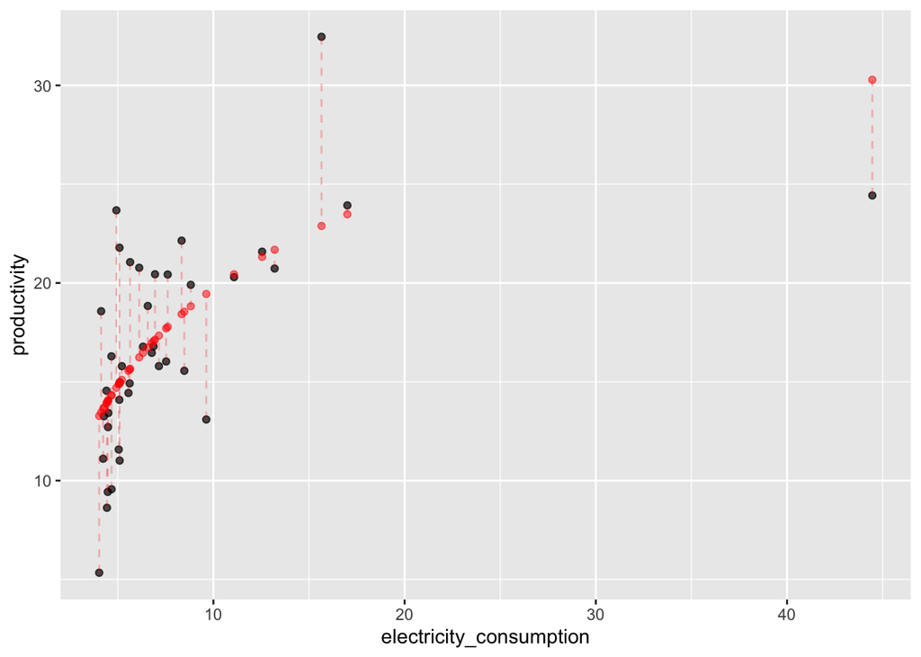

```r
ggplot(df, aes(x = electricity_consumption, y = productivity)) +
  geom_point(alpha = 0.7) +
  geom_point(aes(x = electricity_consumption, y = log_lm$fitted.values), color = "red", alpha = 0.5) +
  geom_segment(aes(xend = electricity_consumption, yend = log_lm$fitted.values), color = "red", alpha = 0.25, linetype = "dashed")
```

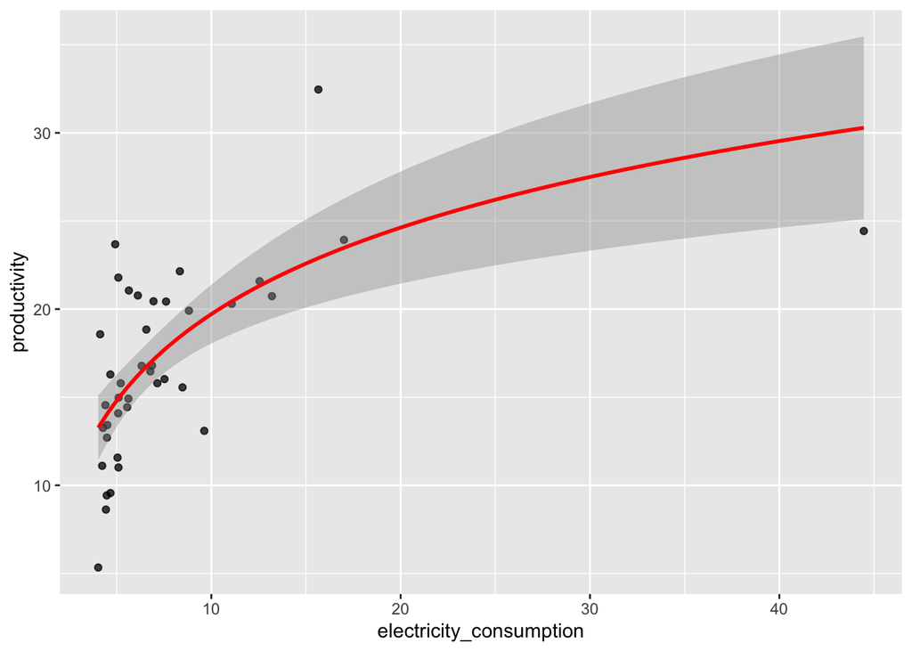

```r
ggplot(df, aes(x = electricity_consumption, y = productivity)) +
  geom_point(alpha = 0.75) +
  geom_smooth(method = "lm", formula = y ~ log(x), color = "red")
```

### 2.2. Other Log transformation

```r
other_log_lm <- lm(log(productivity) ~ electricity_consumption, data = df)
summary(log_lm)
```

```
##
## Call:
## lm(formula = productivity ~ log(electricity_consumption), data = df)
##
## Residuals:
##     Min      1Q  Median      3Q     Max
## -7.9331 -1.8846 -0.3487  2.0075  9.5712
##
## Coefficients:
##                              Estimate Std. Error t value Pr(>|t|)
## (Intercept)                     3.400      2.552   1.332    0.191
## log(electricity_consumption)    7.085      1.306   5.423 3.52e-06 ***
## ---
## Signif. codes:  0 '***' 0.001 '**' 0.01 '*' 0.05 '.' 0.1 ' ' 1
##
## Residual standard error: 3.975 on 38 degrees of freedom
## Multiple R-squared:  0.4363, Adjusted R-squared:  0.4215
## F-statistic: 29.41 on 1 and 38 DF,  p-value: 3.518e-06
```

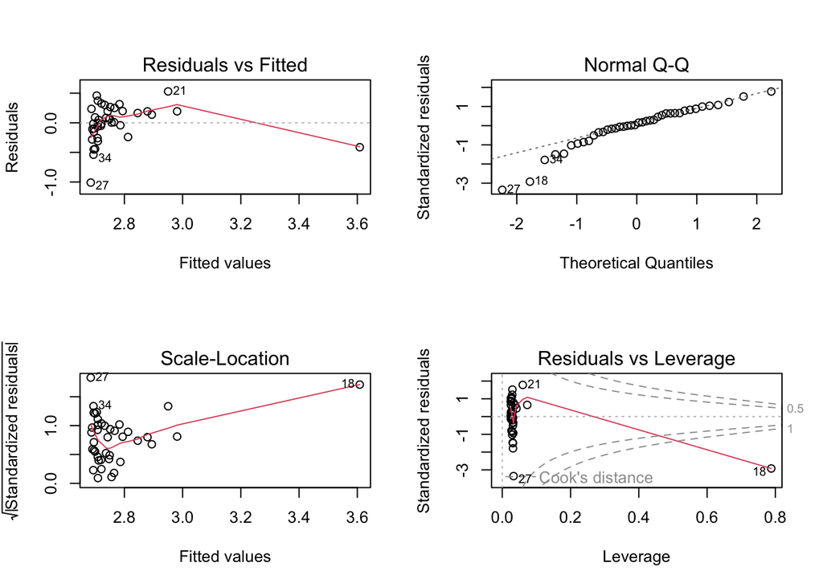

```r
par(mfrow = c(2,2))
plot(other_log_lm)
```

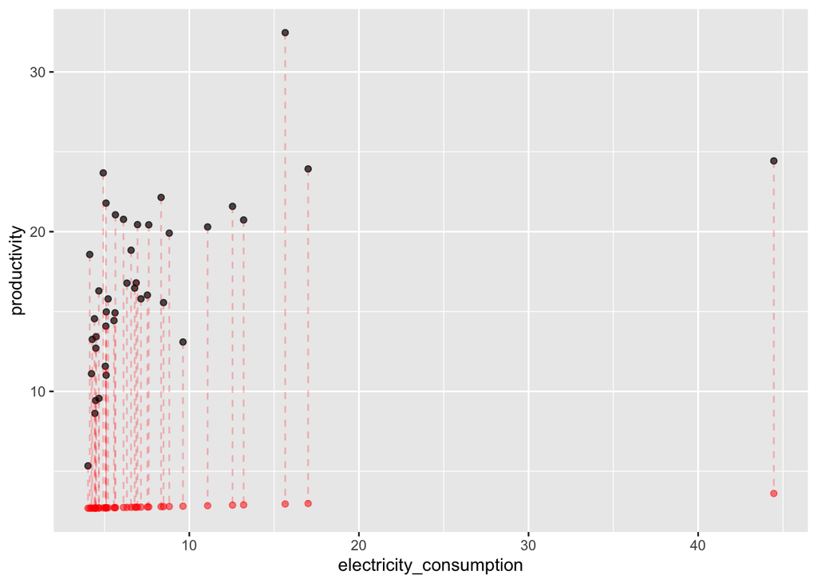

```r
ggplot(df, aes(x = electricity_consumption, y = productivity)) +
  geom_point(alpha = 0.7) +
  geom_point(aes(x = electricity_consumption, y = other_log_lm$fitted.values), color = "red", alpha = 0.5) +
  geom_segment(aes(xend = electricity_consumption, yend = other_log_lm$fitted.values), color = "red", alpha = 0.25, linetype = "dashed")
```

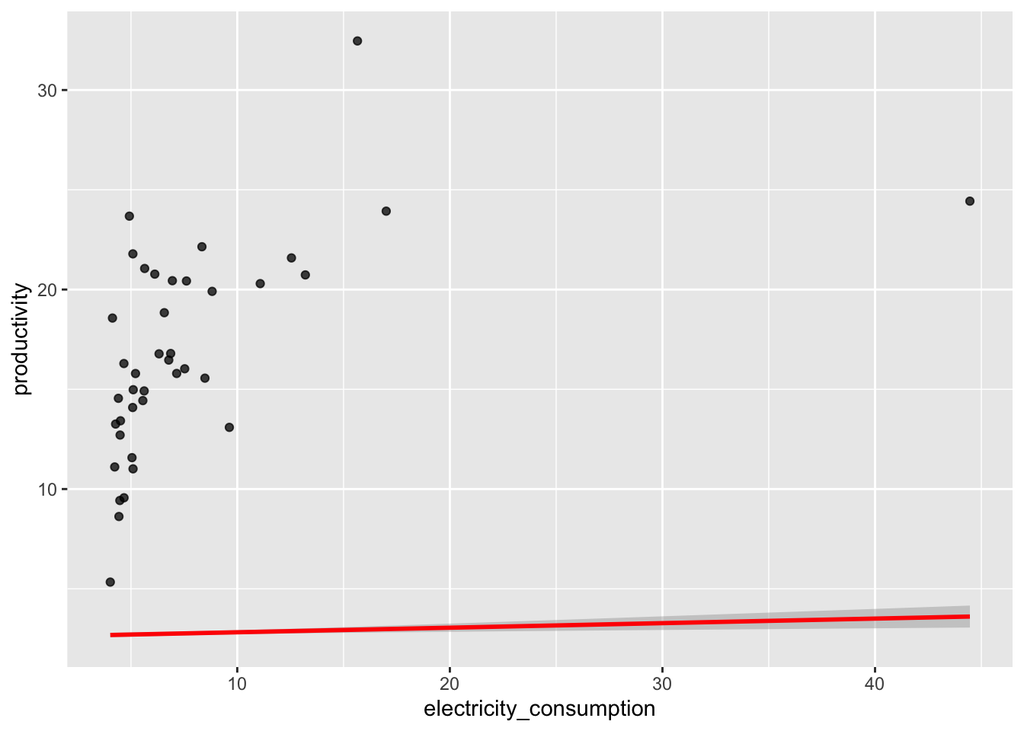

```r
ggplot(df, aes(x = electricity_consumption, y = productivity)) +
  geom_point(alpha = 0.75) +
  geom_smooth(method = "lm", formula = log(y) ~ x, color = "red")
```